# Introduction

This is a transnational data set which contains all the transactions occurring between 01/12/2010 and 09/12/2011 for a UK-based and registered non-store online retail.

# Data set Column Description

| Variable Name | Role | Type | Description | Units | Missing Values |
| --- | --- | --- | --- | --- | --- |
| InvoiceNo | ID | Categorical | a 6-digit integral number uniquely assigned to each transaction. If this code starts with letter ‘c’, it indicates a cancellation |  | no |
| StockCode | ID | Categorical | a 5-digit integral number uniquely assigned to each distinct product |  | no |
| Description | Feature | Categorical | product name |  | no |
| Quantity | Feature | Integer | the quantities of each product (item) per transaction |  | no |
| InvoiceDate | Feature | Date | the day and time when each transaction was generated |  | no |
| UnitPrice | Feature | Continuous | product price per unit | sterling | no |
| CustomerID | Feature | Categorical | a 5-digit integral number uniquely assigned to each customer |  | no |
| Country | Feature | Categorical | the name of the country where each customer resides |  | no |

# Data Preparations

- Loading the dataset:

```r
library(dplyr)
```

```r
library(ggplot2)
library(lubridate)
library(tidyr)
library(skimr)
library(cowplot)
```

- Initial data exploration:

```r
library(readxl)
retail_data<- read_excel("D:/test teknikal kerja/kita lulus/pakai R/online+retail/Online Retail.xlsx")
head(retail_data)
```

| InvoiceNo | StockCode | Description | Quantity | InvoiceDate | UnitPrice | CustomerID | Country |
| --- | --- | --- | --- | --- | --- | --- | --- |
| 536365 | 85123A | WHITE HANGING HEART T-LIGHT HOLDER | 6 | 2010-12-01 08:26:00 | 2.55 | 17850 | United Kingdom |
| 536365 | 71053 | WHITE METAL LANTERN | 6 | 2010-12-01 08:26:00 | 3.39 | 17850 | United Kingdom |
| 536365 | 84406B | CREAM CUPID HEARTS COAT HANGER | 8 | 2010-12-01 08:26:00 | 2.75 | 17850 | United Kingdom |
| 536365 | 84029G | KNITTED UNION FLAG HOT WATER BOTTLE | 6 | 2010-12-01 08:26:00 | 3.39 | 17850 | United Kingdom |
| 536365 | 84029E | RED WOOLLY HOTTIE WHITE HEART. | 6 | 2010-12-01 08:26:00 | 3.39 | 17850 | United Kingdom |
| 536365 | 22752 | SET 7 BABUSHKA NESTING BOXES | 2 | 2010-12-01 08:26:00 | 7.65 | 17850 | United Kingdom |

Let’s try to check some missing values in the dataset, and also check for the structure and statistical descriptive.

```r
colSums(is.na(retail_data))
```

```
##   InvoiceNo   StockCode Description    Quantity InvoiceDate   UnitPrice
##           0           0        1454           0           0           0
##  CustomerID     Country
##      135080           0
```

```r
# Chech data structure
str(retail_data)
```

```
## tibble [541,909 × 8] (S3: tbl_df/tbl/data.frame)
##  $ InvoiceNo  : chr [1:541909] "536365" "536365" "536365" "536365" ...
##  $ StockCode  : chr [1:541909] "85123A" "71053" "84406B" "84029G" ...
##  $ Description: chr [1:541909] "WHITE HANGING HEART T-LIGHT HOLDER" "WHITE METAL LANTERN" "CREAM CUPID HEARTS COAT HANGER" "KNITTED UNION FLAG HOT WATER BOTTLE" ...
##  $ Quantity   : num [1:541909] 6 6 8 6 6 2 6 6 6 32 ...
##  $ InvoiceDate: POSIXct[1:541909], format: "2010-12-01 08:26:00" "2010-12-01 08:26:00" ...
##  $ UnitPrice  : num [1:541909] 2.55 3.39 2.75 3.39 3.39 7.65 4.25 1.85 1.85 1.69 ...
##  $ CustomerID : num [1:541909] 17850 17850 17850 17850 17850 ...
##  $ Country    : chr [1:541909] "United Kingdom" "United Kingdom" "United Kingdom" "United Kingdom" ...
```

```r
# Check statistical descriptive
summary(retail_data)
```

```
##   InvoiceNo          StockCode         Description           Quantity
##  Length:541909      Length:541909      Length:541909      Min.   :-80995.00
##  Class :character   Class :character   Class :character   1st Qu.:     1.00
##  Mode  :character   Mode  :character   Mode  :character   Median :     3.00
##                                                           Mean   :     9.55
##                                                           3rd Qu.:    10.00
##                                                           Max.   : 80995.00
##
##   InvoiceDate                       UnitPrice           CustomerID
##  Min.   :2010-12-01 08:26:00.00   Min.   :-11062.06   Min.   :12346
##  1st Qu.:2011-03-28 11:34:00.00   1st Qu.:     1.25   1st Qu.:13953
##  Median :2011-07-19 17:17:00.00   Median :     2.08   Median :15152
##  Mean   :2011-07-04 13:34:57.16   Mean   :     4.61   Mean   :15288
##  3rd Qu.:2011-10-19 11:27:00.00   3rd Qu.:     4.13   3rd Qu.:16791
##  Max.   :2011-12-09 12:50:00.00   Max.   : 38970.00   Max.   :18287
##                                                       NA's   :135080
##    Country
##  Length:541909
##  Class :character
##  Mode  :character
##
##
##
##
```

```r
# Check for missing values (NA)
colSums(is.na(retail_data))
```

```
##   InvoiceNo   StockCode Description    Quantity InvoiceDate   UnitPrice
##           0           0        1454           0           0           0
##  CustomerID     Country
##      135080           0
```

- Handling Missing Values:

```r
# Percentage of missing CustomerID values
missing_customerID <- sum(is.na(retail_data$CustomerID)) / nrow(retail_data) * 100
cat("Percentage of missing CustomerID values:", missing_customerID, "%\n\n")
```

```
## Percentage of missing CustomerID values: 24.92669 %
```

```r
#make a new table for a cleaned data
retail_clean <- retail_data
# Verify that no NA values exist in important columns now
cat("Sums of Missing Values\n\n")
```

```
## Sums of Missing Values
```

```r
colSums(is.na(retail_clean))
```

```
##   InvoiceNo   StockCode Description    Quantity InvoiceDate   UnitPrice
##           0           0        1454           0           0           0
##  CustomerID     Country
##      135080           0
```

- Create a TotalSales column by multiply quantity with unitprice and start to convert the invoicedate column to month-day-year hour-minute formats.

```r
# Create a new column for TotalPrice
retail_clean1 <- retail_clean %>%
  mutate(TotalSales = Quantity * UnitPrice)

# Convert InvoiceDate to a datetime object for time series analysis
retail_clean$InvoiceDate <- as.POSIXct(retail_clean$InvoiceDate, format = "%m/%d/%Y %H:%M")
```

- Visualization of customer for all transaction events (not cancelled), cancelled transactions, free items, discounts, etc.) for better understanding about where the customer come from.

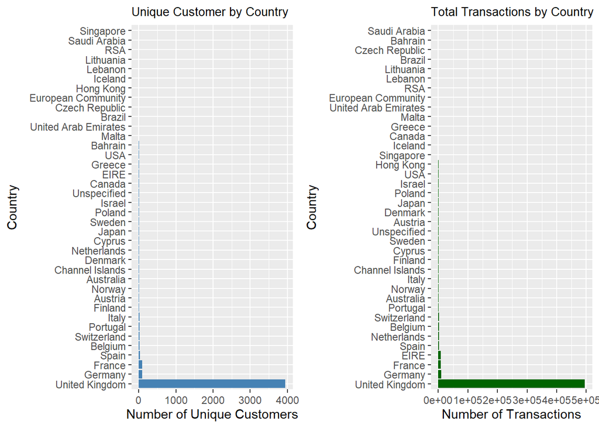

```r
par(mfrow=c(1,2))
# Group by Country and count unique customers
customer_base_per_country <- retail_clean1 %>%
  group_by(Country) %>%
  summarise(UniqueCustomers = n_distinct(CustomerID)) %>%
  arrange(desc(UniqueCustomers))
# Group by Country and count total transactions
transactions_per_country <- retail_clean1 %>%
  group_by(Country) %>%
  summarise(TotalTransactions = n()) %>%
  arrange(desc(TotalTransactions))

# Visualize customer base per country using a bar chart
plot1<- ggplot(customer_base_per_country, aes(x = reorder(Country, -UniqueCustomers), y = UniqueCustomers)) +
  geom_bar(stat = "identity", fill = "steelblue") +
  coord_flip() + # Flip the chart for better readability
  labs(title = "Unique Customer by Country", x = "Country", y = "Number of Unique Customers") +
  theme(plot.title = element_text(size = 10))
#Visualize transactions per country using a bar chart
plot2<-ggplot(transactions_per_country, aes(x = reorder(Country, -TotalTransactions), y = TotalTransactions)) +
  geom_bar(stat = "identity", fill = "darkgreen") +
  coord_flip() + # Flip the chart for better readability
  labs(title = "Total Transactions by Country", x = "Country", y = "Number of Transactions") +
  theme(plot.title = element_text(size = 10)) # Change the font size of the title here
# plot two plots in a grid
plot_grid(plot1, plot2)
```

As you can see, the top three countries for both categories are consistently the UK, Germany, and France. Interestingly, EIRE (Ireland) has a low number of unique customers but ranks fourth in total transactions. This suggests that there maybe loyal customers making multiple purchases.

Since most transactions come from the UK and are an outlier, let’s take a look at other countries besides the UK for more detailed insights.

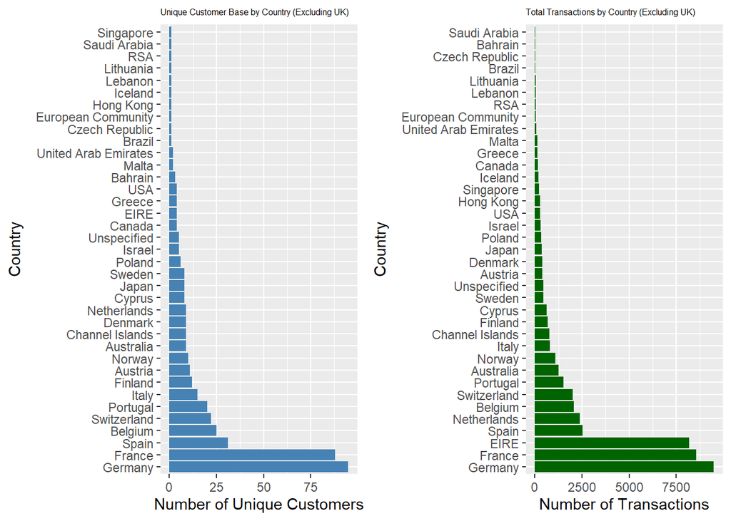

```r
# Group by Country and count total transactions excluding UK
transactions_per_country_no_uk <- retail_clean1 %>%
  filter(Country != "United Kingdom") %>%  # Exclude UK
  group_by(Country) %>%
  summarise(TotalTransactions = n()) %>%
  arrange(desc(TotalTransactions))

# Visualize transactions per country excluding UK
plot3<-ggplot(transactions_per_country_no_uk, aes(x = reorder(Country, -TotalTransactions), y = TotalTransactions)) +
  geom_bar(stat = "identity", fill = "darkgreen") +
  coord_flip() +  # Flip for better readability
  labs(title = "Total Transactions by Country (Excluding UK)", x = "Country", y = "Number of Transactions") +
  theme(plot.title = element_text(size = 6))
# Group by Country and count unique customers excluding UK
customer_base_per_country_no_uk <- retail_clean %>%
  filter(Country != "United Kingdom") %>%  # Exclude UK
  group_by(Country) %>%
  summarise(UniqueCustomers = n_distinct(CustomerID)) %>%
  arrange(desc(UniqueCustomers))

# Visualize customer base per country excluding UK
plot4<-ggplot(customer_base_per_country_no_uk, aes(x = reorder(Country, -UniqueCustomers), y = UniqueCustomers)) +
  geom_bar(stat = "identity", fill = "steelblue") +
  coord_flip() +  # Flip for better readability
  labs(title = "Unique Customer Base by Country (Excluding UK)", x = "Country", y = "Number of Unique Customers") +
  theme(plot.title = element_text(size = 6))

# plot two plots in a grid
plot_grid(plot4, plot3)
```

Now we can see a more detailed graph, which shows that EIRE has fewer than 25 unique customers, yet over 7,500 transactions occurred. We may need further analysis to determine whether there are specific loyal customers driving these transactions.

Next, we will examine what times customers are making their transactions.

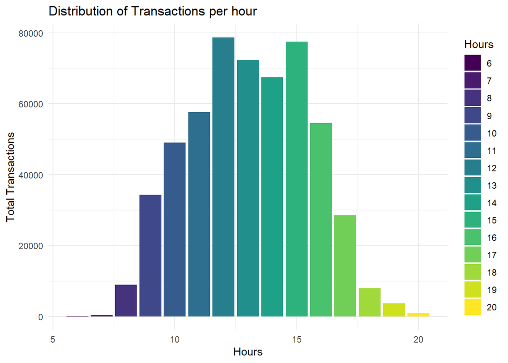

```r
# Tambahkan kolom Jam Transaksi berdasarkan jam dari InvoiceDate
retail_clean1 <- retail_clean1 %>%
  mutate(
    Hour = hour(InvoiceDate)
  )

# Hitung jumlah transaksi per jam
transactions_per_hour <- retail_clean1 %>%
  group_by(Hour) %>%
  summarise(TotalTransactions = n()) %>%
  arrange(Hour)

# Visualisasi distribusi transaksi per jam
ggplot(transactions_per_hour, aes(x = Hour, y = TotalTransactions, fill = as.factor(Hour))) +
  geom_bar(stat = "identity") +
  labs(title = "Distribution of Transactions per hour", x = "Hours", y = "Total Transactions") +
  scale_fill_viridis_d(name = "Hours") +
  theme_minimal()
```

- Checking for anomalies in data:
  - Negative Quantities: Orders with negative quantities could represent cancellations or returns. We’ll check and handle them.
  - Unusual Unit Prices: We also want to check for any unusual prices, such as negative or zero values.

We will not remove the NA values from the Descriptions because there are many categories with missing values, and their Unit Price is 0. Consequently, all unwanted values in the descriptions will be eliminated when we address the Unit Price of 0, as they do not contribute to sales calculations.

```r
# Checking for zero prices
zero_prices <- retail_clean %>% filter(UnitPrice == 0)
cat("Number of transactions with zero prices:", nrow(zero_prices), "\n")
```

```
## Number of transactions with zero prices: 2515
```

```r
# Remove transactions with zero prices (keep negative prices)
retail_clean1 <- retail_clean1 %>%
  filter(UnitPrice != 0)
#remove customer id
retail_clean1 <- retail_clean1 %>%
  select(-CustomerID)
# Verify that no NA values exist in important columns now
colSums(is.na(retail_clean1))
```

```
##   InvoiceNo   StockCode Description    Quantity InvoiceDate   UnitPrice
##           0           0           0           0           0           0
##     Country  TotalSales        Hour
##           0           0           0
```

Now, we will conduct a deeper analysis of the cancelled transactions. ditahap ini, produk akan dibagi menjadi tiga: 1. Produk yang mempunyai huruf A diawal InvoiceNo akan diberi label Adjusted 2. Produk yang mempunyai huruf C diawal InvoiceNo akan diberi label Cancelled 3. Selain itu, akan diberi label Not Cancelled

```r
# Add a new column to mark cancellations and adjustments.
retail_clean1 <- retail_clean1 %>%
  mutate(IsCancelled = ifelse(grepl("^C", InvoiceNo), "Cancelled",
                              ifelse(grepl("^A", InvoiceNo), "Adjusted", "Not Cancelled")))

# Count the number of transactions based on cancellation status.
cancelled_summary <- retail_clean1 %>%
  group_by(IsCancelled) %>%
  summarise(Count = n())

# Show summary
print(cancelled_summary)
```

```
## # A tibble: 3 × 2
##   IsCancelled    Count
##   <chr>          <int>
## 1 Adjusted           3
## 2 Cancelled       9288
## 3 Not Cancelled 530103
```

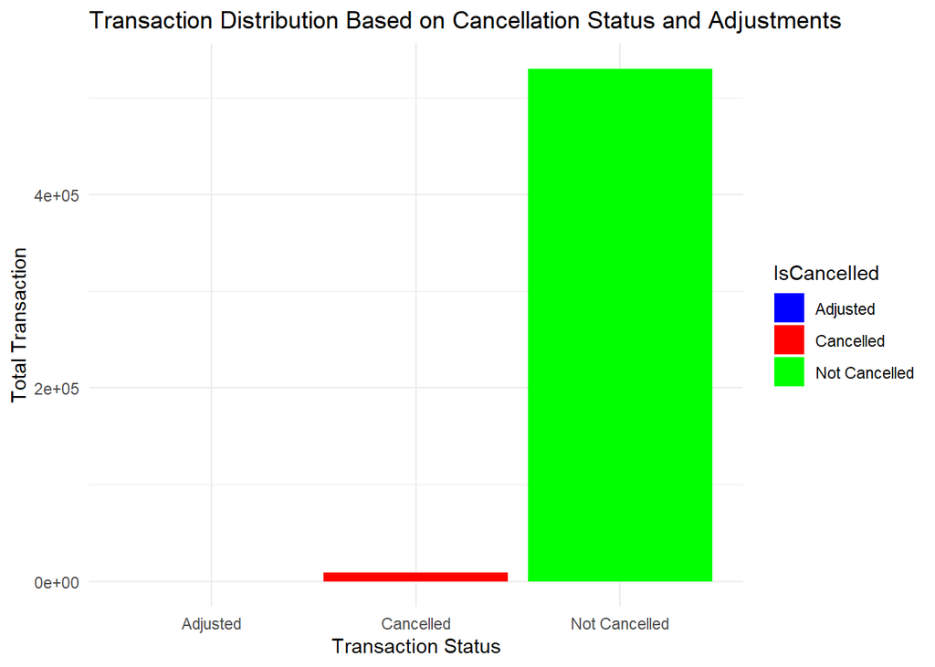

```r
# Visualize the distribution of transactions based on cancellation status and adjustments.
ggplot(cancelled_summary, aes(x = IsCancelled, y = Count, fill = IsCancelled)) +
  geom_bar(stat = "identity") +
  labs(title = "Transaction Distribution Based on Cancellation Status and Adjustments",
       x = "Transaction Status", y = "Total Transaction") +
  scale_fill_manual(values = c("Cancelled" = "red", "Adjusted" = "blue", "Not Cancelled" = "green")) +
  theme_minimal()
```

There are 3 products labeled as adjusted, 9,288 products that were cancelled, and 530,103 products that were sold. For a clearer picture, please refer to the visualization above.

Because there are several cancelled products, we will take a quick look to see whether these cancelled products affect total sales.

```r
#products contribute most to sales
top30_product_sales <- retail_clean1 %>%
  select(StockCode, Description, TotalSales)%>%
  group_by(StockCode, Description, TotalSales) %>%
  filter(rank(desc(TotalSales)) <= 30) %>%
  arrange(desc(TotalSales)) %>%
  head(30)
head(top30_product_sales, 30)
```

| StockCode | Description | TotalSales |
| --- | --- | --- |
| 23843 | PAPER CRAFT , LITTLE BIRDIE | 168469.60 |
| 23166 | MEDIUM CERAMIC TOP STORAGE JAR | 77183.60 |
| 22502 | PICNIC BASKET WICKER 60 PIECES | 38970.00 |
| AMAZONFEE | AMAZON FEE | 13541.33 |
| B | Adjust bad debt | 11062.06 |
| POST | POSTAGE | 8142.75 |
| 23243 | SET OF TEA COFFEE SUGAR TINS PANTRY | 7144.72 |
| 21108 | FAIRY CAKE FLANNEL ASSORTED COLOUR | 6539.40 |
| 21108 | FAIRY CAKE FLANNEL ASSORTED COLOUR | 6539.40 |
| 23084 | RABBIT NIGHT LIGHT | 4992.00 |

[output cut: 20 more lines]

It can be seen in the top 30 highest selling prices that there are several items such as bad adjustment debt, postage, Amazon fees, and manuals that do not actually contribute to product sales. Of course, these need to be eliminated. However, we will first look to see if they are still related to the value of the cancelled products

```r
# Selecting top total sales with respective invoices tocheck for cancelled orders
check_canceled <- retail_clean1 %>%
  select(InvoiceNo, StockCode, Description, Quantity, TotalSales, IsCancelled)%>%
  filter(abs(TotalSales) %in% c(168469.60,77183.60,38970.00,13541.33,11062.06,8142.75   ,   7144.72 ,   6539.40 ,   6539.40,    4992.00,4921.50 ,   4781.60 ,   4632.00 ,   4522.50 ,   4505.17 ,   4401.00 ,   4287.63 ,   4254.50 ,   4176.00 ,   4161.06 ,4161.06    ,   4121.64 ,3949.32    ,   3861.00 ,   3828.00 ,   3825.36 ,   3794.40 ,   3700.00 ,   3651.60 ,   3621.00)) %>%
  arrange(desc(abs(TotalSales)))
check_canceled
```

| InvoiceNo | StockCode | Description | Quantity | TotalSales | IsCancelled |
| --- | --- | --- | --- | --- | --- |
| 581483 | 23843 | PAPER CRAFT , LITTLE BIRDIE | 80995 | 168469.60 | Not Cancelled |
| C581484 | 23843 | PAPER CRAFT , LITTLE BIRDIE | -80995 | -168469.60 | Cancelled |
| 541431 | 23166 | MEDIUM CERAMIC TOP STORAGE JAR | 74215 | 77183.60 | Not Cancelled |
| C541433 | 23166 | MEDIUM CERAMIC TOP STORAGE JAR | -74215 | -77183.60 | Cancelled |
| 556444 | 22502 | PICNIC BASKET WICKER 60 PIECES | 60 | 38970.00 | Not Cancelled |
| C556445 | M | Manual | -1 | -38970.00 | Cancelled |
| C537630 | AMAZONFEE | AMAZON FEE | -1 | -13541.33 | Cancelled |
| 537632 | AMAZONFEE | AMAZON FEE | 1 | 13541.33 | Not Cancelled |
| C537651 | AMAZONFEE | AMAZON FEE | -1 | -13541.33 | Cancelled |
| A563185 | B | Adjust bad debt | 1 | 11062.06 | Adjusted |

[output cut: 28 more lines]

It turns out that some of those top products are indeed cancelled items, bad adjustment debt, postage, Amazon fees, and manuals. Therefore, they need to be removed from the data.

```r
retail_clean1 <- retail_clean1 %>%
  filter(!StockCode %in% c("DOT", "POST", "M", "AMAZONFEE", "B"))

# Daftar InvoiceNo yang ingin dihapus
invoices_to_remove <- c("581483","C581484", "541431",   "556444","C541433", "540815",   "C550456",  "540818",   "C550456",  "540815",   "C550456")

# Menghapus baris di mana InvoiceNo berada dalam daftar
retail_clean1 <- retail_clean1 %>%
  filter(!(InvoiceNo %in% invoices_to_remove))
```

After that, perform another check for the top 30 products.

```r
#Check again
#products contribute most to sales
top30_product_sales <- retail_clean1 %>%
  select(StockCode, Description, TotalSales)%>%
  group_by(StockCode, Description, TotalSales) %>%
  filter(rank(desc(TotalSales)) <= 30) %>%
  arrange(desc(TotalSales)) %>%
  head(30)
head(top30_product_sales, 30)
```

| StockCode | Description | TotalSales |
| --- | --- | --- |
| 23243 | SET OF TEA COFFEE SUGAR TINS PANTRY | 7144.72 |
| 21108 | FAIRY CAKE FLANNEL ASSORTED COLOUR | 6539.40 |
| 23084 | RABBIT NIGHT LIGHT | 4992.00 |
| 22086 | PAPER CHAIN KIT 50'S CHRISTMAS | 4781.60 |
| 85123A | WHITE HANGING HEART T-LIGHT HOLDER | 4632.00 |
| 23173 | REGENCY TEAPOT ROSES | 4401.00 |
| 48185 | DOORMAT FAIRY CAKE | 4254.50 |
| 84879 | ASSORTED COLOUR BIRD ORNAMENT | 4176.00 |
| 22470 | HEART OF WICKER LARGE | 4121.64 |
| 22413 | METAL SIGN TAKE IT OR LEAVE IT | 3861.00 |

[output cut: 20 more lines]

At the very least, the products that are likely to contribute significantly to sales are now free from irrelevant data. However, I would like to conduct a further check by searching for data that exhibits the same patterns as the data that has been removed for all rows.

```r
library(dplyr)
# Identify pairs with opposite quantities and matching total sales
similar_pattern <- retail_clean1 %>%
  group_by(StockCode) %>%
  filter(Quantity == -lead(Quantity) | Quantity == -lag(Quantity)) %>%
  filter(abs(TotalSales) == abs(lead(TotalSales)) | abs(TotalSales) == abs(lag(TotalSales))) %>%
  ungroup()

# Remove identified matching pairs from the original dataset
retail_clean_filtered <- retail_clean1 %>%
  anti_join(similar_pattern, by = c("InvoiceNo", "StockCode", "Quantity", "TotalSales"))
```

The above code has removed indications of data input errors, preventing items that should have been cancelled from being recorded as not cancelled. Additionally, data will also be removed for all cancelled items (sample items, discounted items, and similar).

```r
# Menghapus semua baris dengan status "Cancelled"
retail_clean_filtered <- retail_clean_filtered %>%
  filter(IsCancelled != "Cancelled")

# Tampilkan dataset yang sudah difilter
summary(retail_clean_filtered)
```

```
##   InvoiceNo          StockCode         Description           Quantity
##  Length:524701      Length:524701      Length:524701      Min.   :   1.00
##  Class :character   Class :character   Class :character   1st Qu.:   1.00
##  Mode  :character   Mode  :character   Mode  :character   Median :   3.00
##                                                           Mean   :  10.23
##                                                           3rd Qu.:  11.00
##                                                           Max.   :4800.00
##   InvoiceDate                       UnitPrice         Country
##  Min.   :2010-12-01 08:26:00.00   Min.   :  0.001   Length:524701
##  1st Qu.:2011-03-28 12:13:00.00   1st Qu.:  1.250   Class :character
##  Median :2011-07-20 13:53:00.00   Median :  2.080   Mode  :character
##  Mean   :2011-07-04 21:30:11.96   Mean   :  3.263
##  3rd Qu.:2011-10-19 14:05:00.00   3rd Qu.:  4.130
##  Max.   :2011-12-09 12:50:00.00   Max.   :649.500
##    TotalSales            Hour       IsCancelled
##  Min.   :   0.001   Min.   : 6.00   Length:524701
##  1st Qu.:   3.750   1st Qu.:11.00   Class :character
##  Median :   9.900   Median :13.00   Mode  :character
##  Mean   :  18.833   Mean   :13.08
##  3rd Qu.:  17.460   3rd Qu.:15.00
##  Max.   :7144.720   Max.   :20.00
```

It can be seen from the summary above that the data is now clean of all cancelled products, mislabelled items, and other factors that do not contribute to sales.

# Finalized Result of Exploratory Data Analysis (EDA):

## Top 10 Selling Items:

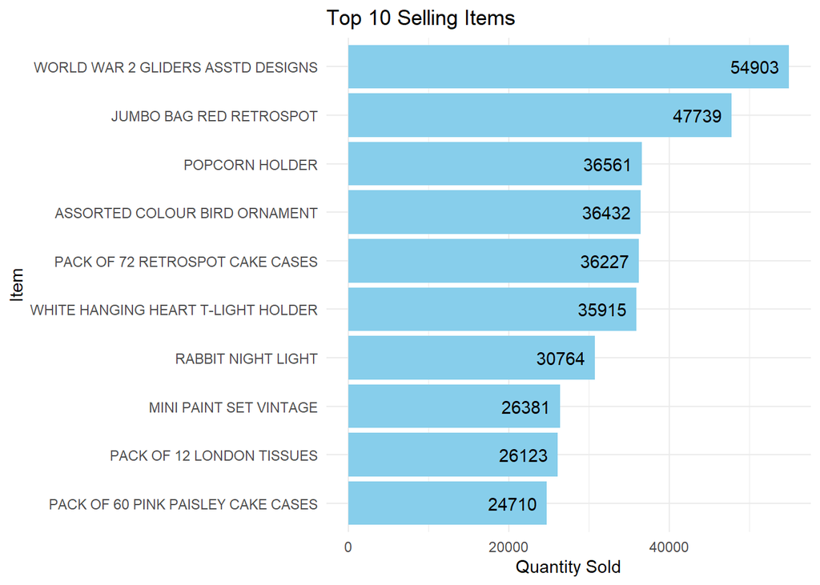

```r
# Top 10 most sold items based on Quantity
top_items <- retail_clean_filtered %>%
  group_by(Description) %>%
  summarise(TotalQuantity = sum(Quantity)) %>%
  arrange(desc(TotalQuantity)) %>%
  head(10)

ggplot(top_items, aes(x = reorder(Description, TotalQuantity), y = TotalQuantity)) +
  geom_bar(stat = "identity", fill = "skyblue") +
  coord_flip() +
  geom_text(aes(label = TotalQuantity), hjust = 1.2) +  # Menambahkan angka pada bar
  labs(title = "Top 10 Selling Items", x = "Item", y = "Quantity Sold") +
  theme_minimal()
```

The image above shows the top 10 items that have been sold the most/most purchased by customers. The highest sales are led by the product ‘World War 2 Gliders ASSTD Designs,’ which sold 54,903 units.

Next, we will examine the top 10 products with the highest sum of total sales value.

```r
# Top 10 products contribute most to sales
top10_product_sales <- retail_clean_filtered %>%
  select(StockCode, Description, TotalSales) %>%
  group_by(StockCode, Description) %>%  # Group by StockCode and Description only
  summarise(TotalSales = sum(TotalSales, na.rm = TRUE)) %>%  # Summarize total sales
  arrange(desc(TotalSales)) %>%
  head(10)
```

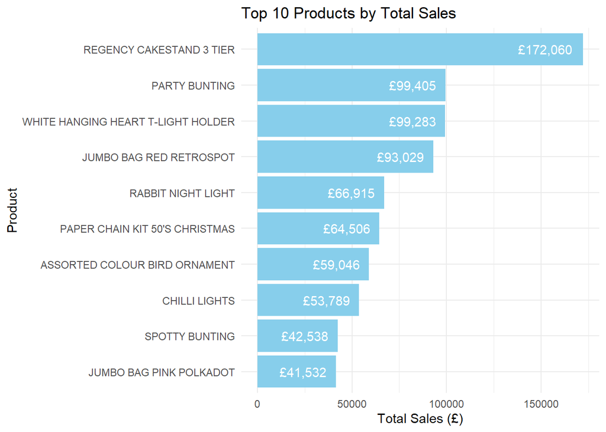

```r
# Bar chart visualization
ggplot(top10_product_sales, aes(x = reorder(Description, TotalSales), y = TotalSales)) +
  geom_bar(stat = "identity", fill = "skyblue") +
  coord_flip() +
  geom_text(aes(label = scales::dollar(TotalSales, prefix = "£")), hjust = 1.2, color = "white") +  # Angka di dalam bar
  labs(title = "Top 10 Products by Total Sales", x = "Product", y = "Total Sales (£)") +
  theme_minimal()
```

It can be seen that the product ‘Regency Cakestand 3 Tier’ has the highest total sales value at £172,060.

## Sales Trend Over Time:

Previously, we will separate the year, month, and day into their own individual columns.

```r
# Separate the InvoiceDate column into Year, Month, and Day.
retail_clean_filtered <- retail_clean_filtered %>%
  mutate(Year = format(as.Date(InvoiceDate), "%Y"),   # For Year
         Month = format(as.Date(InvoiceDate), "%m"),  # For Month
         Day = format(as.Date(InvoiceDate), "%d"))    # For Day

# Check the results of the separated columns
head(retail_clean_filtered)
```

| InvoiceNo | StockCode | Description | Quantity | InvoiceDate | UnitPrice | Country | TotalSales | Hour | IsCancelled | Year | Month | Day |
| --- | --- | --- | --- | --- | --- | --- | --- | --- | --- | --- | --- | --- |
| 536365 | 85123A | WHITE HANGING HEART T-LIGHT HOLDER | 6 | 2010-12-01 08:26:00 | 2.55 | United Kingdom | 15.30 | 8 | Not Cancelled | 2010 | 12 | 01 |
| 536365 | 71053 | WHITE METAL LANTERN | 6 | 2010-12-01 08:26:00 | 3.39 | United Kingdom | 20.34 | 8 | Not Cancelled | 2010 | 12 | 01 |
| 536365 | 84406B | CREAM CUPID HEARTS COAT HANGER | 8 | 2010-12-01 08:26:00 | 2.75 | United Kingdom | 22.00 | 8 | Not Cancelled | 2010 | 12 | 01 |
| 536365 | 84029G | KNITTED UNION FLAG HOT WATER BOTTLE | 6 | 2010-12-01 08:26:00 | 3.39 | United Kingdom | 20.34 | 8 | Not Cancelled | 2010 | 12 | 01 |
| 536365 | 84029E | RED WOOLLY HOTTIE WHITE HEART. | 6 | 2010-12-01 08:26:00 | 3.39 | United Kingdom | 20.34 | 8 | Not Cancelled | 2010 | 12 | 01 |
| 536365 | 22752 | SET 7 BABUSHKA NESTING BOXES | 2 | 2010-12-01 08:26:00 | 7.65 | United Kingdom | 15.30 | 8 | Not Cancelled | 2010 | 12 | 01 |

Now, let’s take a look at the daily and monthly sales trends:

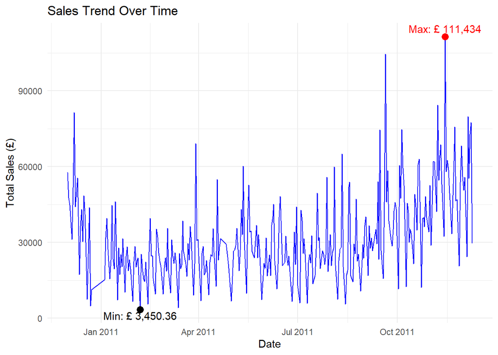

```r
# Calculate Sales Trends
sales_trend <- retail_clean_filtered %>%
  mutate(Date = as.Date(InvoiceDate)) %>%
  group_by(Date) %>%
  summarise(DailySales = sum(TotalSales, na.rm = TRUE))

# Determine Dates with Highest and Lowest Sales
max_sales <- sales_trend %>% filter(DailySales == max(DailySales, na.rm = TRUE))
min_sales <- sales_trend %>% filter(DailySales == min(DailySales, na.rm = TRUE))

# Visualize Daily Sales Trends
ggplot(sales_trend, aes(x = Date, y = DailySales)) +
  geom_line(color = "blue") +
  geom_point(data = max_sales, aes(x = Date, y = DailySales), color = "red", size = 3, shape = 16) +
  geom_text(data = max_sales, aes(x = Date, y = DailySales, label = paste("Max: £", scales::dollar(DailySales, prefix = ""))), vjust = -0.5, color = "red") +
  geom_point(data = min_sales, aes(x = Date, y = DailySales), color = "black", size = 3, shape = 16) +
  geom_text(data = min_sales, aes(x = Date, y = DailySales, label = paste("Min: £", scales::dollar(DailySales, prefix = ""))), vjust = 1.25, color = "black") +
  labs(title = "Sales Trend Over Time", x = "Date", y = "Total Sales (£)") +
  theme_minimal()
```

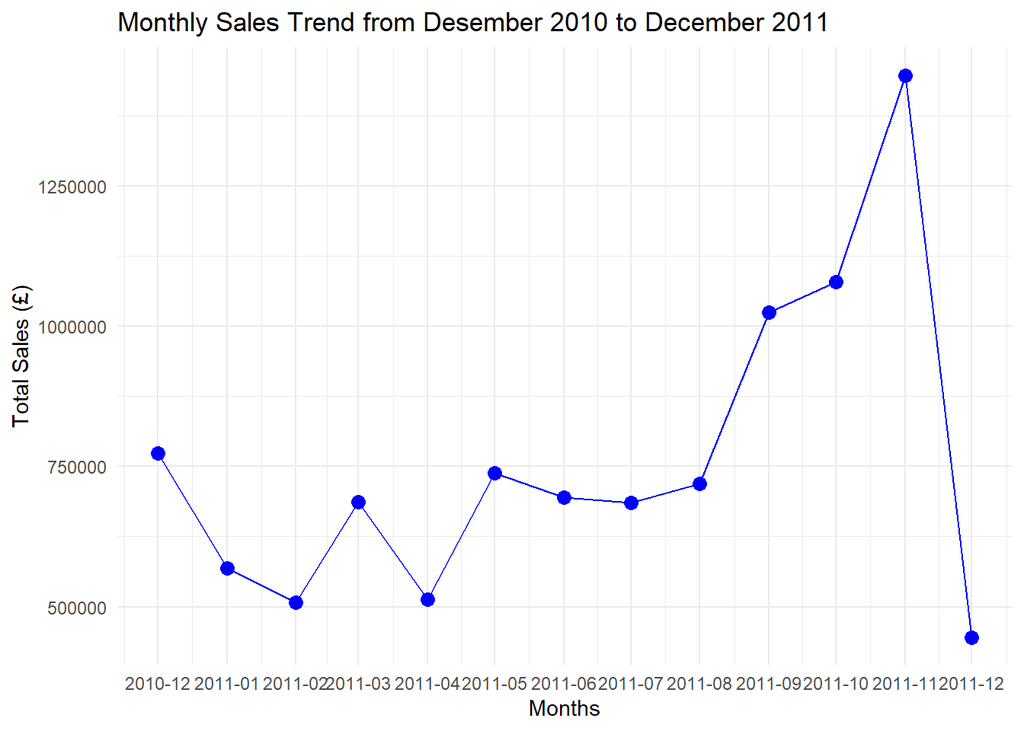

```r
#-----------------------------------------------------------------------------------------------
# Ensure Year and Month Columns are Character or Factor Types
retail_clean_filtered <- retail_clean_filtered %>%
  mutate(Year = as.character(Year),
         Month = as.character(Month))

# Filter Data from January 2010 to December 2011
filtered_data <- retail_clean_filtered %>%
  filter((Year == "2010" & Month >= "01" & Month <= "12") |
         (Year == "2011" & Month >= "01" & Month <= "12"))

# Combine Year and Month into a YearMonth Column
filtered_data <- filtered_data %>%
  mutate(YearMonth = paste(Year, Month, sep = "-"))

# Calculate Total Sales per Month
monthly_sales <- filtered_data %>%
  group_by(YearMonth) %>%
  summarise(MonthlySales = sum(TotalSales, na.rm = TRUE))

# Sort by YearMonth for Accurate Visualization
monthly_sales <- monthly_sales %>%
  arrange(ymd(paste(YearMonth, "01", sep = "-")))
# Visualize Monthly Trends
ggplot(monthly_sales, aes(x = ymd(paste(YearMonth, "01", sep = "-")), y = MonthlySales)) +
  geom_line(color = "blue") +
  geom_point(color = "blue", size = 3) +
  labs(title = "Monthly Sales Trend from Desember 2010 to December 2011", x = "Months", y = "Total Sales (£)") +
  theme_minimal() +
  scale_x_date(date_labels = "%Y-%m", date_breaks = "1 month")
```

1. Daily Sales
- It can be seen that the trend is quite fluctuating, peaking at the end of 2011, likely due to the upcoming New Year and Christmas celebrations. In terms of daily sales values, the lowest daily sales recorded is £3,450.36, while the highest is £111,434.
2. Monthly Sales
- For monthly sales, there is a slight bias due to the data for December 2011 not covering a full month, which makes the data a bit skewed. However, overall, the peak sales occur in November 2011.

# Conclusion

1. The majority of buyers come from the UK, which is expected as transactions are conducted in sterling, the currency of the UK.
2. An interesting observation from the customer analysis by country of origin is the potential presence of loyal customers from EIRE (Ireland), indicated by the low number of unique customers but a high volume of transactions. This warrants a deeper analysis of customer behavior.
3. Overall, sales are quite fluctuating, peaking in November 2011. This is sensitive to missing and incomplete data. One contributing factor is the high number of transaction records that do not significantly impact overall sales.
4. A deeper analysis of customer behavior is necessary to gain more accurate insights that can be used for making larger-scale decisions.